# Ciência de Dados para Todos (Data Science For All) - 2019.2 - Análise da Produção Científica e Acadêmica da Universidade de Brasília - Relatório - Departamento de Ciência da Computação da UnB

### 7.0.3 Arquivo Orientação

O gráfico ilustra a quantidade de orientações por ano (em forma de barras):

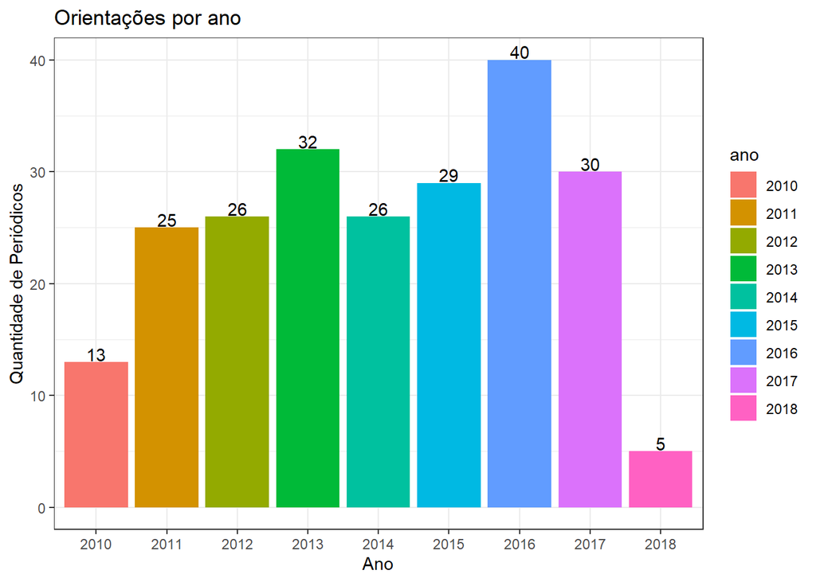

```r
orient.df %>%
  ggplot(aes(x = ano)) + geom_bar(aes(fill = ano)) +
  geom_text(stat = "count", aes(label = formatC(..count.., big.mark = ",")), vjust =
              -0.1) +
  theme_bw() + labs(title = "Orientações por ano", x = "Ano", y = "Quantidade de Periódicos") +
  scale_y_continuous(labels = comma)
```

Podemos observar teve um crescimento alto de orientações em 2016, mas teve decrescimento muito baixo em 2018.

O gráfico ilustra a quantidade de orientações completas por ano (em forma de barras):

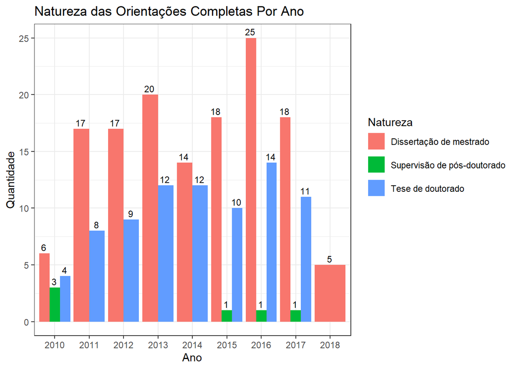

```r
ggplot(orient.df, aes(ano, fill = factor(natureza))) +
  geom_bar(stat = "count", position = "dodge") +
  ggtitle("Natureza das Orientações Completas Por Ano") +
  theme(legend.position = "right", legend.text = element_text(size = 7)) +
  guides(fill = guide_legend(
    nrow = 5,
    byrow = TRUE,
    title.position = "top"
  )) +
  labs(x = "Ano", y = "Quantidade") + labs(fill = "Natureza") + theme_bw() +
  geom_text(
    hjust = 0.6,
    vjust = -0.4,
    size = 3,
    color = 'black',
    position = position_dodge(width = 0.9),
    stat = "count",
    aes(
      group = factor(natureza),
      label = formatC(..count.., big.mark = ",")
    ), check_overlap = TRUE)
```

Podemos observar teve um crescimento alto de dissertação de mestrado e tese de doutorado em 2016 e pouca supervisão de pós-doutorado.

O gráfico ilustra a quantidade de orientações completas por ano (em forma de linhas e pontos):

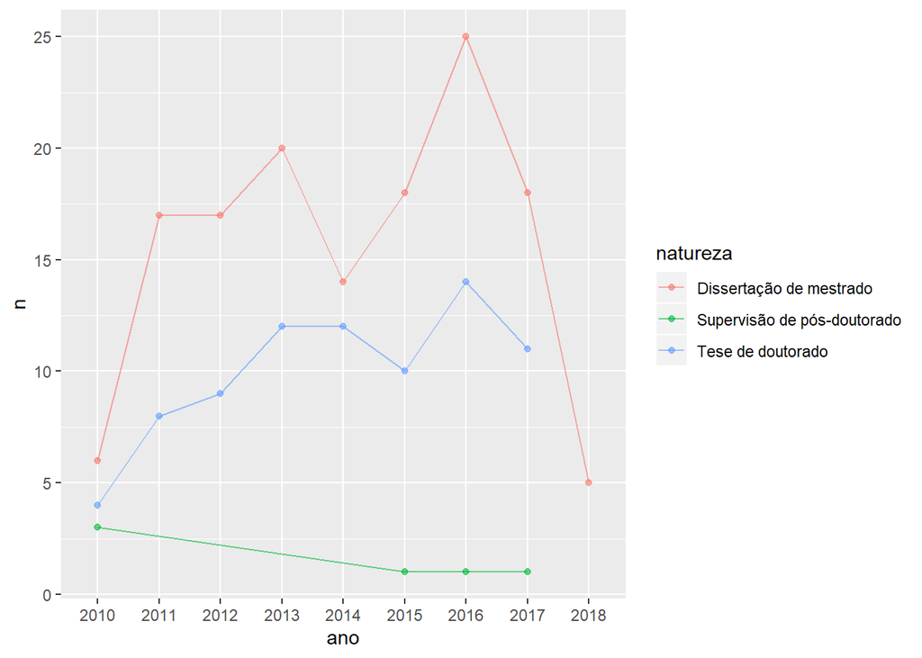

```r
ggplot(orient_sum, aes(
  x = ano,
  y = n,
  group = natureza,
  color = natureza
)) +
  geom_line(alpha = 0.6) +
  geom_point(alpha = 0.6)
```

## 7.1 Revisão do processo

Por meio das análises realizadas nas seções anteriores, tem-se que a modelagem de análise com os modelos estatísticos foram adequados para esse projeto, uma vez que permitiu a obtenção de resultados não triviais em relação aos dois programas de pós-graduação analisados.

Tem-se ainda que os modelos e os datasets em que se aplicaram os modelos nesse relatório são facilmente verificáveis e replicáveis por meio da leitura desse documento.

# 8 Fase 6 - Implantação (deployment)

Na fase de implantação, realiza-se o planejamento da implantação dos scripts desenvolvidos para o ambiente operacional. Os scripts desenvolvidos nesse trabalho permitem uma análise de dados do programa de pós-graduação sob outros pontos de vista, que podem trazer estatísticas e relações não triviais.

# 9 Conclusão

Esse trabalho mostrou uma forma de analisar dados de arquivos .json utilizando as técnicas da CRISP-DM. Dessa forma foi possível aprender sobre a ciência de dados e as possíveis análises que ela pode proporcionar; como os dados devem ser preparados; como deve-se buscar informações úteis e analisa-las; como gerar gráficos visualmente mais adequados, usa tecnicas grafos para analíse de redes e a dificuldade que a falta de padronização pode causar, principalmente quando existem diversos arquivos para analisar de diferentes fontes.

Tendo como base modelo do relatório disponibilizados no aprender UnB da disciplina e implementando os scripts em R com técnicas de analise de redes com igraph e manipulação de dados em R, análise crítica das melhores formas de gerar os gráficos de acordo com os tipos de dados, foi possível fazer uma analise de dados dos datasets de Geotecnia seguindo as 6 fases do CRISP-DM.

Por fim, os resultados obtidos podem ser considerados relevantes e bem-sucedidos para o conjunto de dados, e os resultados são coerentes ao comparar as pontuações de avaliação quadrienal, que colocam o programa Geotecnia como um programa nota 6 que possui um número alto de publicações acadêmicas e orientações acadêmicas.

# Referências

Bharat, Mishra. 2019. “**Understanding Crisp-Dm Using Video Game Sales Data**.” https://medium.com/@imBharatMishra/understanding-crisp-dm-using-video-game-sales-data-a2d55c7a2593.

Capes. 2006. “**Sucupira**.” https://sucupira.capes.gov.br/sucupira/.

CRISP-DM. 2006. “**CRISP-Dm**.” https://www.ibm.com/support/knowledgecenter/en/SS3RA7_15.0.0/com.ibm.spss.crispdm.help/crisp_overview.htm.

Fernandes, Jorge H C, and Ricardo Barros Sampaio. 2011. “**Unb.elattes**.” http://unb.elattes.com.br/.

Geotecnia, Sucupira. 2013. “**Sucupira Geotecnia**.” https://sucupira.capes.gov.br/sucupira/public/consultas/coleta/programa/viewPrograma.jsf?popup=true&cd_programa=53001010032P2.

Sucupira. 2006. “**Sucupira**.” https://www.capes.gov.br/acessoainformacao/91-conteudo-estatico/avaliacao-capes/6871-caracterizacao-do-sistema-de-avaliacao-da-pos-graduacao.

Todamateria. 2006. “**O Que é Ciência?**” https://www.todamateria.com.br/o-que-e-ciencia/.

UnB. 2006. “**UnB**.” https://www.unb.br/pesquisa.